# Тюменцева Арина Владиславовна Б22-701_Вариант 25

Tyumentseva

2024-11-18

### **ОТЧËТ**

**по лабораторной работе №3 (вариант 25)**  
**по дисциплине:** «Статистика»

**Выполнил:** студент группы Б22-701  
**Тюменцева Арина Владиславовна**

**Проверил:** Смирнов Д. С.

Москва, 2024 г.

### Введение:

В исходных данных приведены пороговые значения концентрации отдельных веществ в населенных пунктах, при превышении которых, по вине фирмы, её ждет штраф.

В исходных данных приведены оценочные затраты на установку очистного оборудования, для отдельного вида опасных веществ и затрат на их годовую эксплуатацию.

В исходных данных приведены показатели суточного мониторинга концентраций опасных веществ в атмосфере на территории завода, за последние 10 лет.

К сожалению, за прошлые годы, систематический мониторинг концентраций опасных веществ на территории поселка городского типа не производился, однако научной группе из НИИ Метеорологии и Климатологии СО РАН удалась создать модель переноса веществ от источника загрязнения к поселку, с учетом рельефа и природных особенностей местности. В упрощенном виде, эффективность переноса зависит только от направления ветра.

### Проблема:

необходимо определить оптимальную стратегию: нести существенные первоначальные капитальные затраты на оборудование для контроля загрязнения или принять риск потенциально значительных совокупных штрафов за загрязнение окружающей среды в течение пятилетнего периода, при этом сбалансировав ожидаемые затраты обоих подходов.

#### **Цель работы**:

на основе анализа известных статистических данных дать обоснованную рекомендацию, о выборе стратегии уменьшения негативного влияния на ближайшие 5 лет.

#### **Ход работы:**

#### **Задание 1: загрузить материалы индивидуального проекта**

1. Устанавливаем пакет “openxlsx”
2. Загружаем данные по отдельности, с каждого листа, т.к. у нас содержатся разные данные для разных вычислений

```r
library(openxlsx)

data1 <- read.xlsx("/Users/arinatyumentseva/Desktop/3 курс/Лабораторная работа №3/Данные для ЛР.xlsx", sheet = "Данные по выбросам")

data2 <- read.xlsx("/Users/arinatyumentseva/Desktop/3 курс/Лабораторная работа №3/Данные для ЛР.xlsx", sheet = "Прочая информация")

data3 <- read.xlsx("/Users/arinatyumentseva/Desktop/3 курс/Лабораторная работа №3/Данные для ЛР.xlsx", sheet = "Роза Ветров")

data4 <- read.xlsx("/Users/arinatyumentseva/Desktop/3 курс/Лабораторная работа №3/Данные для ЛР.xlsx", sheet = "Оценка эффективности")

head(data1)
```

```
##           X1    Аммиак    Фосген Этиленоксид Диоксид.серы Бромметан
## 1 2013-01-01 10.486263 0.5203802   1.0892610   0.01795602  4.866013
## 2 2013-01-02  9.788141 0.3163646   0.9498651   0.03220240  5.467189
## 3 2013-01-03 12.759305 0.5826449   0.9197450   0.03485293  6.266941
## 4 2013-01-04 14.194465 0.2859495   1.0196108   0.03050292  5.454955
## 5 2013-01-05  5.826577 0.2932154   2.1660162   0.04422186  4.900637
## 6 2013-01-06 16.083132 0.7904396   0.9966147   0.03278802  4.548904
```

```r
head(data2)
```

```
##       Вещество Ед..измерения   ПДК Штраф,.тыс.руб Стоимость.системы,.тыс.руб.
## 1       Аммиак        мг/м^3 20.00             95                        1907
## 2       Фосген        мг/м^3  0.50            205                        4490
## 3  Этиленоксид        мг/м^3  1.00            345                        6296
## 4 Диоксид серы        мг/м^3  0.05            140                        1789
## 5    Бромметан        мг/м^3  5.00             90                        1150
##   Стоимость.обслуживания,.тыс.руб.
## 1                              381
## 2                              898
## 3                             1259
## 4                              358
## 5                              230
```

```r
head(data3)
```

```
##              X1 Дней_в_году
## 1         Север          51
## 2 Северо-восток          11
## 3        Восток          57
## 4    Юго-восток          34
## 5            Юг          36
## 6     Юго-запад          75
```

```r
head(data4)
```

```
##   Направление.ветра.(В.какую.сторону.дует.ветер) Оценка.эффективности
## 1                                          Север                    0
## 2                                  Северо-восток                 0.25
## 3                                         Восток                  0.5
## 4                                     Юго-восток                  0.9
## 5                                             Юг                 0.75
## 6                                      Юго-запад                  0.4
```

#### Задание 2: Оценить совокупные затраты на реализацию первой стратегии (установка очистных сооружений)

*Формула вычисления совокупных затрат за 5 лет для каждого вещества по отдельности:*

Стоимость системы + (Стоимость обслуживания * 5)

```r
element_names <- colnames(data1)[2:length(colnames(data1))]
first_strategy <- data.frame(matrix(nrow = 3, ncol = length(element_names)))
rownames(first_strategy) <- c('Стоимость установки', 'Стоимость обслуживания в год', 'Итого за 5 лет')
names(first_strategy) = element_names
i = 0
for (el in element_names){
  i = i + 1
  first_strategy[1, el] =  data2[i, 'Стоимость.системы,.тыс.руб.']
  first_strategy[2, el] =  data2[i, 'Стоимость.обслуживания,.тыс.руб.']
  first_strategy[3, el] = first_strategy[1, el] + first_strategy[2, el] * 5}
first_strategy
```

```
##                              Аммиак Фосген Этиленоксид Диоксид.серы Бромметан
## Стоимость установки            1907   4490        6296         1789      1150
## Стоимость обслуживания в год    381    898        1259          358       230
## Итого за 5 лет                 3812   8980       12591         3579      2300
```

#### Задание 3: Оценить степень близости **распределений концентраций выбросов** к известным теоретическим законам распределения: **нормальный, гамма, экспоненциальный, вейбулла**.

```r
library(EnvStats)
perform_ks_test <- function(column) {
  column <- na.omit(column)
  gamma_params <- egamma(column)$parameters
  weibull_params <- eweibull(column)$parameters
 list(
    Normal = ks.test(column, "pnorm", mean(column), sd(column))$p.value,
    Gamma = ks.test(column, "pgamma", shape = gamma_params["shape"], scale = gamma_params["scale"])$p.value,
    Exponential = ks.test(column, "pexp", rate = 1 / mean(column))$p.value,
    Weibull = ks.test(column, "pweibull", shape = weibull_params["shape"], scale = weibull_params["scale"])$p.value
  )
}

results <- lapply(data1[-1], perform_ks_test)

results_table <- do.call(rbind, lapply(results, function(res) {
  sapply(res, function(x) round(x, 3))
}))
colnames(results_table) <- c("Normal", "Gamma", "Exponential", "Weibull")
rownames(results_table) <- names(data1)[-1]

print(results_table)
```

```
##              Normal Gamma Exponential Weibull
## Аммиак            0     0           0   0.000
## Фосген            0     0           0   0.447
## Этиленоксид       0     0           0   0.000
## Диоксид.серы      0     0           0   0.000
## Бромметан         0     0           0   0.000
```

H0 : вещество соответствует теоретическому распределению

H1: вещество не соответствует теоретическому распределению

Использовали p-value. Расчёты показали, что только одно вещество соответствует теоретическому распределению, а для остальных p-value = 0. Это означает, что нулевая гипотеза для остальных веществ отвергается, и они не соответствуют теоретическому распределению. p-value эффективно, так как оно учитывает размер выборки.

```r
library(EnvStats)

perform_ks_test <- function(column) {
  column <- na.omit(column)
  gamma_params <- egamma(column)$parameters
  weibull_params <- eweibull(column)$parameters
  list(
    Normal = ks.test(column, "pnorm", mean(column), sd(column))$statistic,
    Gamma = ks.test(column, "pgamma", shape = gamma_params["shape"], scale = gamma_params["scale"])$statistic,
    Exponential = ks.test(column, "pexp", rate = 1 / mean(column))$statistic,
    Weibull = ks.test(column, "pweibull", shape = weibull_params["shape"], scale = weibull_params["scale"])$statistic
  )
}
results_d <- lapply(data1[, -1], perform_ks_test)

results_d_table <- do.call(rbind, lapply(results_d, function(res) {
  sapply(res, function(x) round(x, 3))
}))
rownames(results_d_table) <- names(results_d)
results_d_table <- as.data.frame(results_d_table)
print(results_d_table)
```

```
##              Normal.D Gamma.D Exponential.D Weibull.D
## Аммиак          0.080   0.059         0.393     0.081
## Фосген          0.041   0.042         0.275     0.014
## Этиленоксид     0.117   0.086         0.470     0.146
## Диоксид.серы    0.077   0.049         0.393     0.077
## Бромметан       0.071   0.095         0.428     0.037
```

Используем D для:

- **оценки степени отклонения,** поскольку вещества с малым D будут ближе к теоретическому распределению
- Хотим понять, какие вещества ближе или дальше от теоретического распределения

Выбираем наибольший p-value и наименьший D (тест Колмогорова-Смирнова):

Аммиак: не относится ни к одному из представленных распределений

Фосген: относится в вейбулла-распределению

Этиленоксид: не относится ни к одному из представленных распределений

Диоксид серы: не относится ни к одному из представленных распределений

Бромметан: не относится ни к одному из представленных распределений

#### Задание 4 : Построить графики с отображением **эмпирических и теоретических распределений и плотностей распределений** для сравниваемых **законов.** В случае **невозможности** отнесения распределения к **известным видам -** сформировать **эмпирическую** функцию распределения.

```r
library(fitdistrplus)
```

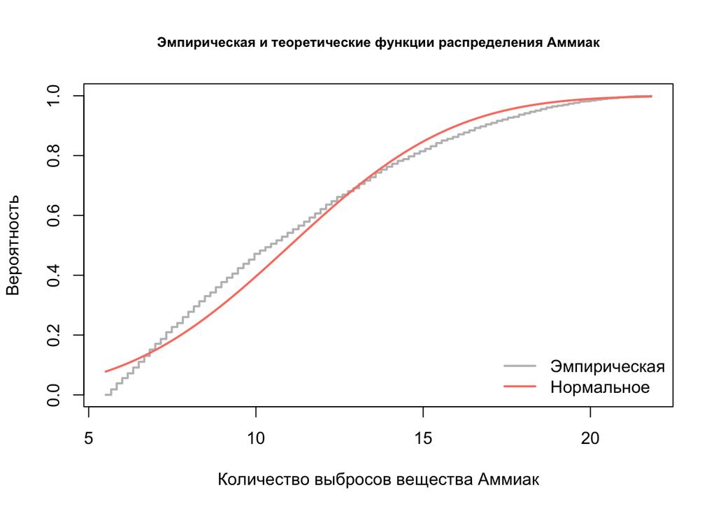

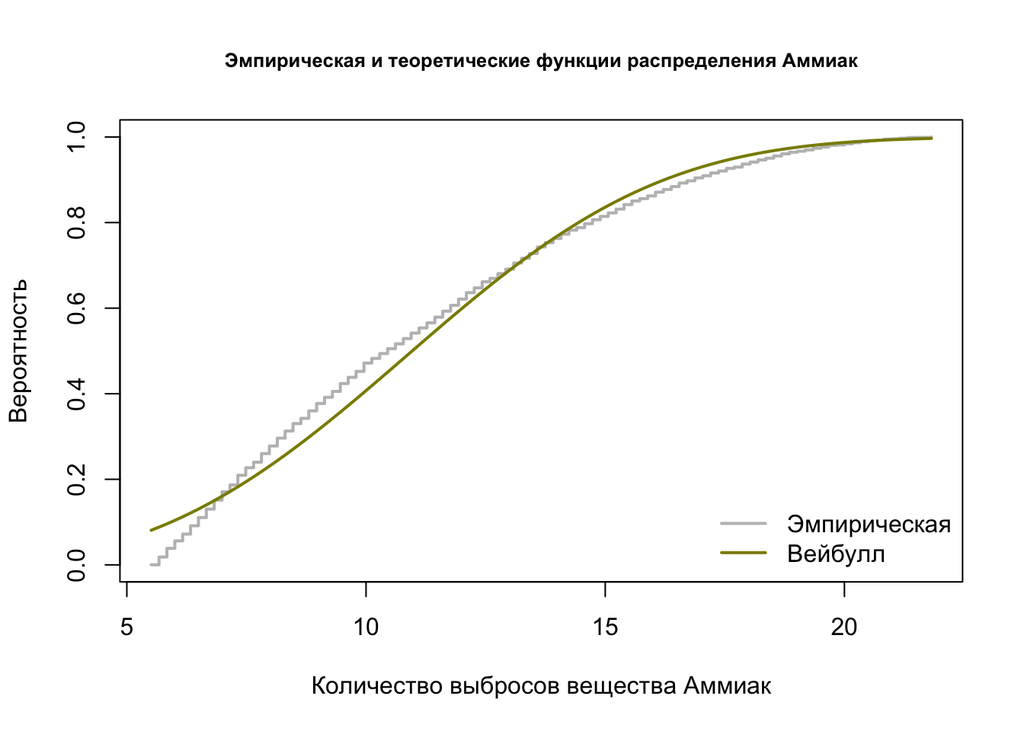

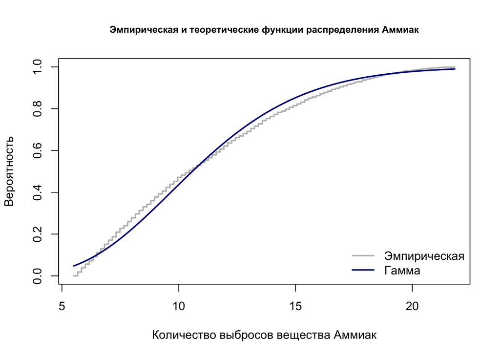

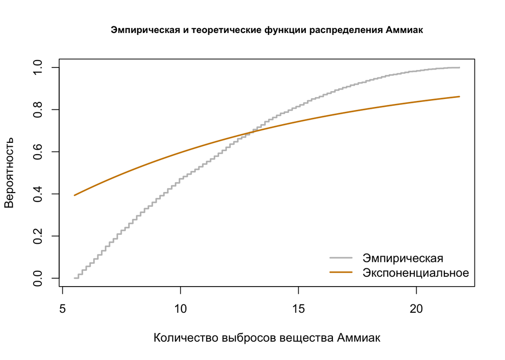

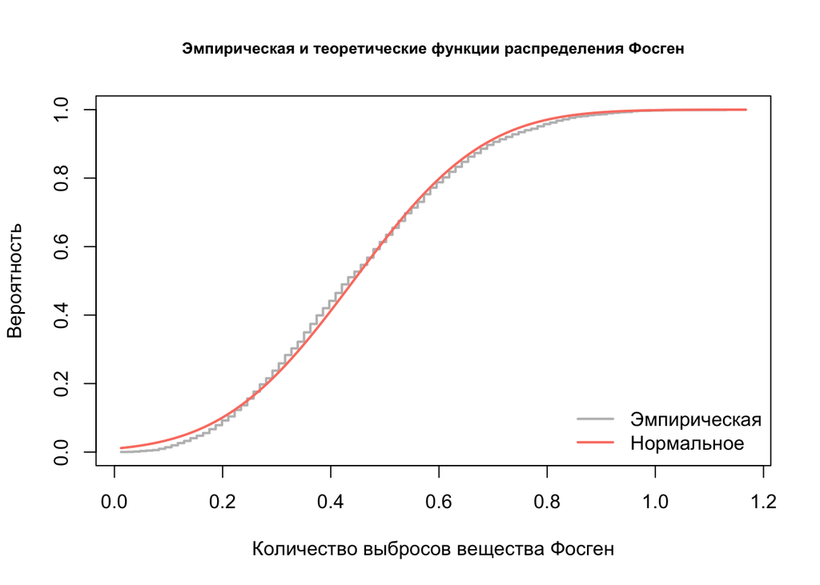

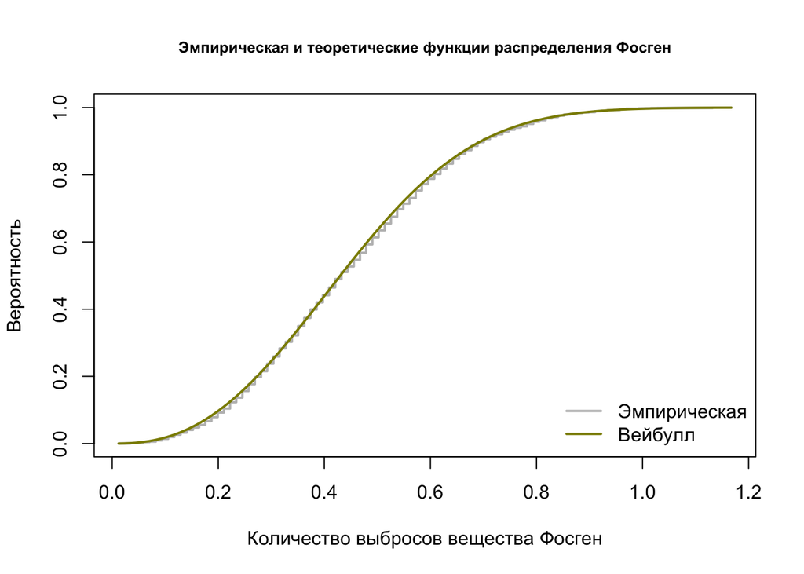

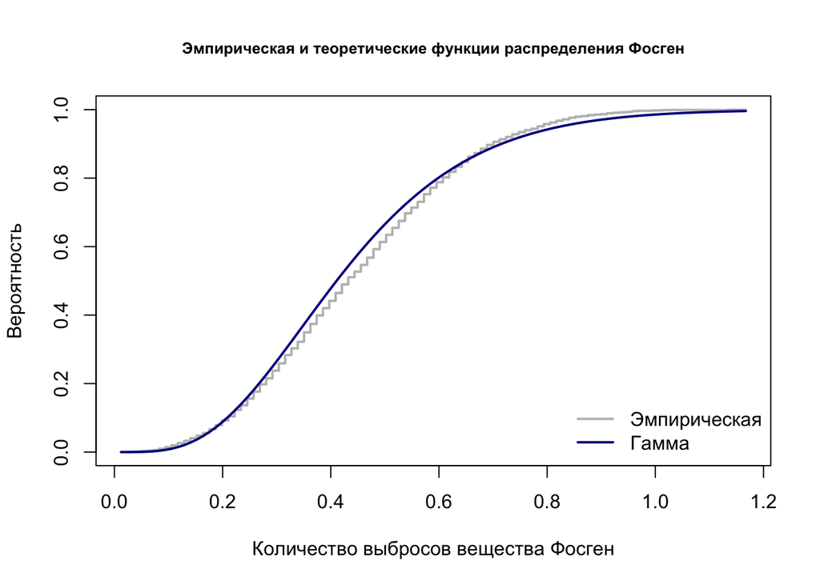

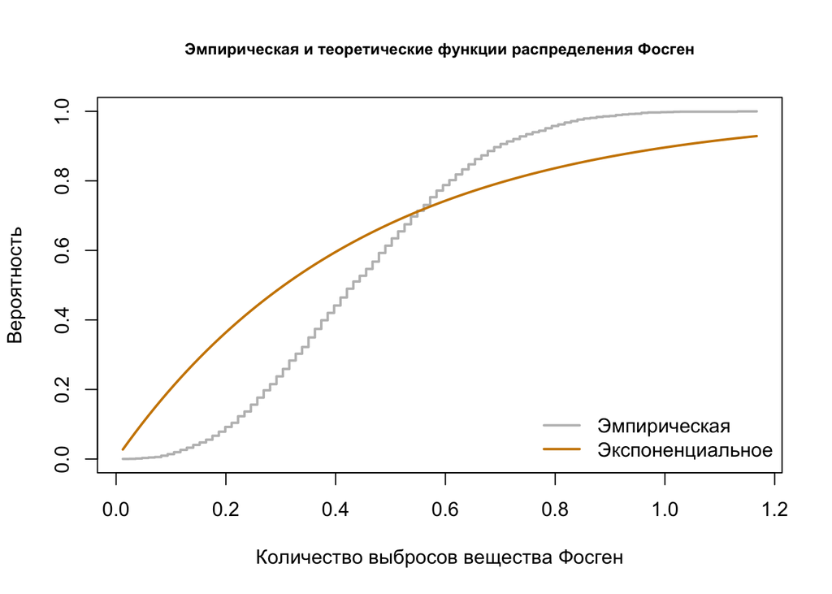

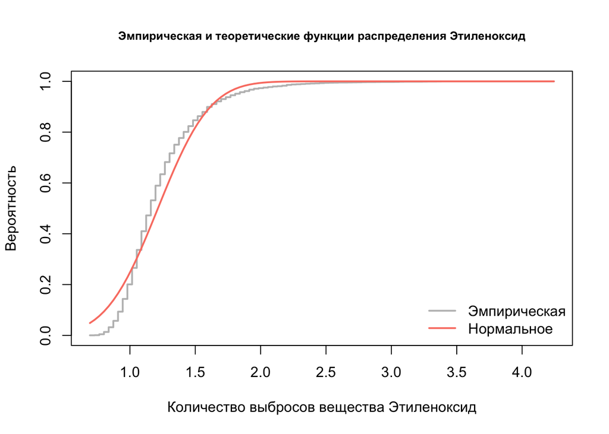

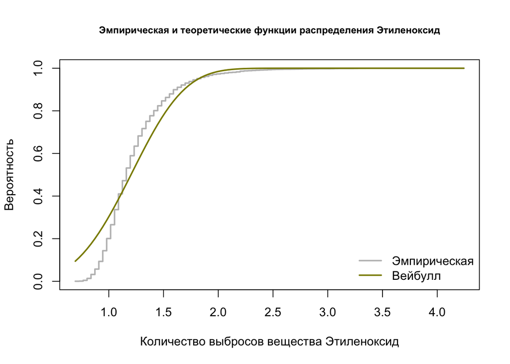

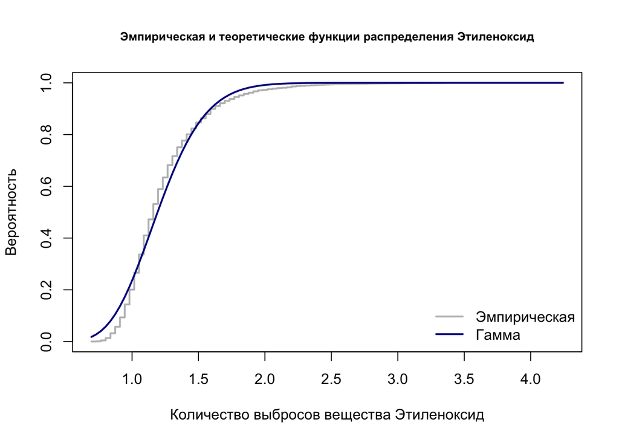

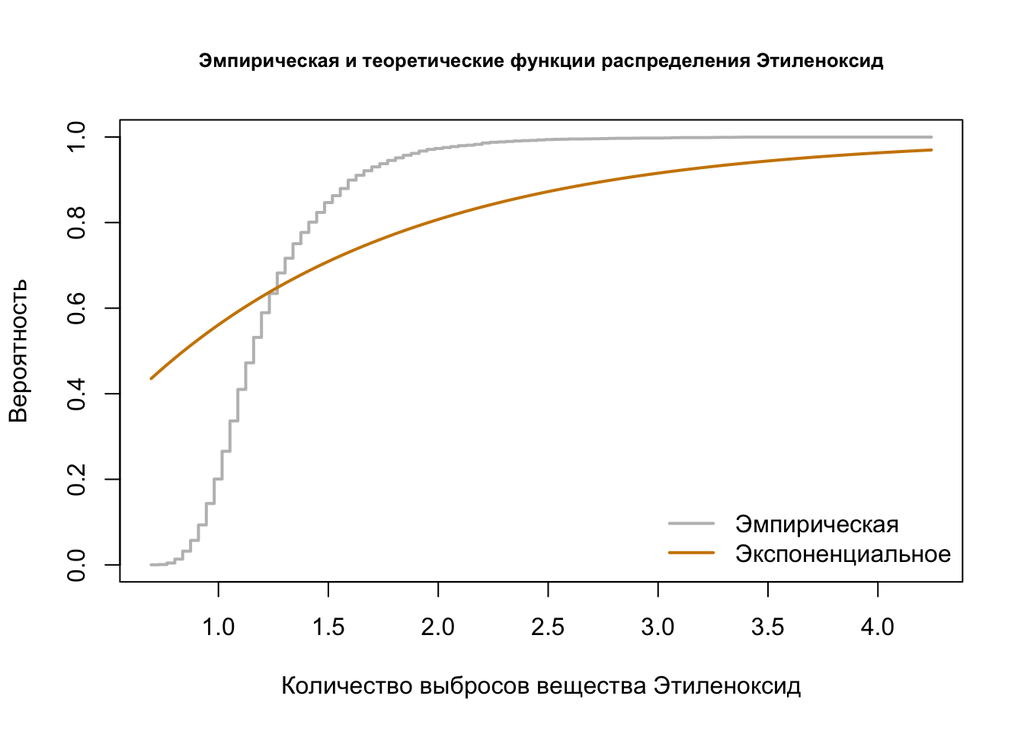

[8 more figures not shown]

```r
substances <- element_names
distributions <- c("norm", "weibull", "gamma", "exp")
for (substance in substances) {
  current_data <- data1[[substance]]
  ecdf_values <- ecdf(current_data)
  x_ecdf <- seq(min(current_data), max(current_data), length.out = 100)
  x_vals <- seq(min(current_data), max(current_data), length.out = 100)

  for (dist in distributions) {
    plot(x_ecdf, ecdf_values(x_ecdf), type = "s",
       main = paste("Эмпирическая и теоретические функции распределения", substance),
       xlab = paste("Количество выбросов вещества", substance),
       ylab = "Вероятность", col = "grey", lwd = 2, cex.main=0.8)

    if (dist == "norm" && all(current_data > 0)) {
      params <- fitdist(current_data, "norm")
      lines(x_vals, pnorm(x_vals, mean = params$estimate[1], sd = params$estimate[2]),col = "salmon", lwd = 2)
        legend("bottomright",
         legend = c("Эмпирическая", "Нормальное"),
         col = c("grey", 'salmon'),
         lwd = 2, bty = "n")

    } else if (dist == "weibull") {
      params <- fitdist(current_data, "weibull")
      lines(x_vals, pweibull(x_vals, shape = params$estimate[1], scale = params$estimate[2]),col = "yellow4", lwd = 2)
        legend("bottomright",
         legend = c("Эмпирическая", "Вейбулл"),
         col = c("grey", "yellow4"),
         lwd = 2, bty = "n")

    } else if (dist == "gamma") {
      params <- fitdist(current_data, "gamma")
      lines(x_vals, pgamma(x_vals, shape = params$estimate[1], rate = params$estimate[2]),col = "blue4", lwd = 2)
        legend("bottomright",
         legend = c("Эмпирическая",  "Гамма"),
         col = c("grey",'blue4'),
         lwd = 2, bty = "n")

    } else if (dist == "exp") {
      params <- fitdist(current_data, "exp",method = "mme")
      lines(x_vals, pexp(x_vals, rate = params$estimate[1]),col = "orange3", lwd = 2)
        legend("bottomright",
         legend = c("Эмпирическая", "Экспоненциальное"),
         col = c("grey", "orange3"),
         lwd = 2, bty = "n")

    }
  }

}
```

Сравнивая линии графиков эмпирической теоретических видов распределений, мы делаем вывод, что:

**Аммиак**: не принадлежит ни к одному из теоретических видов распределений, такой же вывод сделали из теста Колмогорова-Смирнова

**Фосген**: принадлежит к распределению Вейбулла, такой же вывод сделали из теста Колмогорова-Смирнова

**Этиленоксид**: не принадлежит ни к одному из теоретических видов распределений, такой же вывод сделали из теста Колмогорова-Смирнова

**Диоксид серы**: не принадлежит ни к одному из теоретических видов распределений, такой же вывод сделали из теста Колмогорова-Смирнова

**Бромметан**: не принадлежит ни к одному из теоретических видов распределений, такой же вывод сделали из теста Колмогорова-Смирнова

#### Задание 5: Построить гистограммы **распределений**

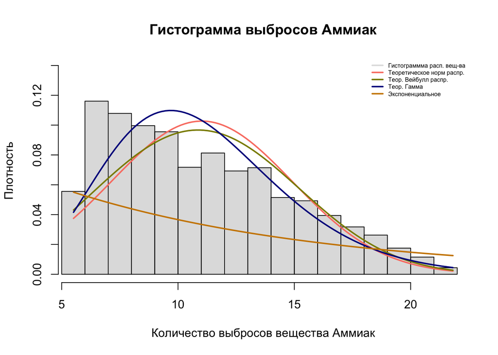

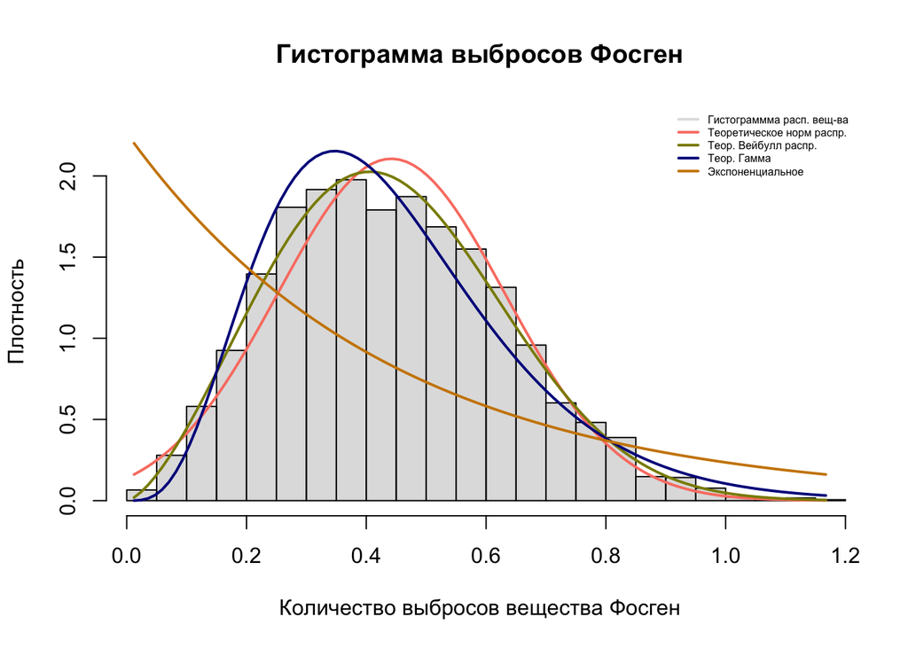

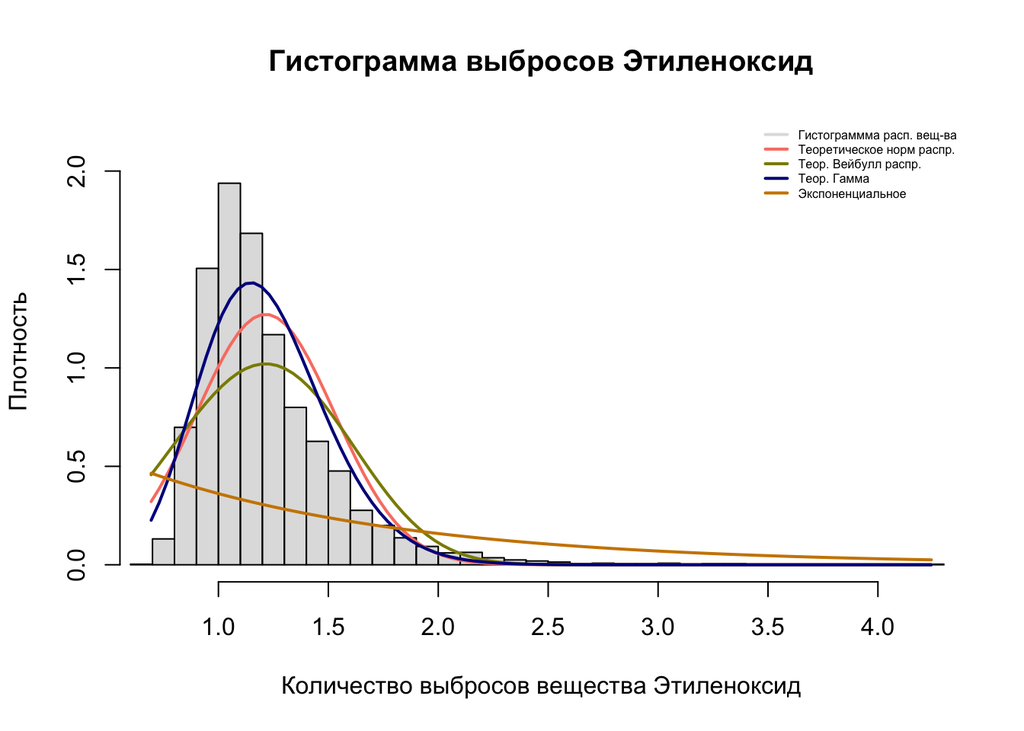

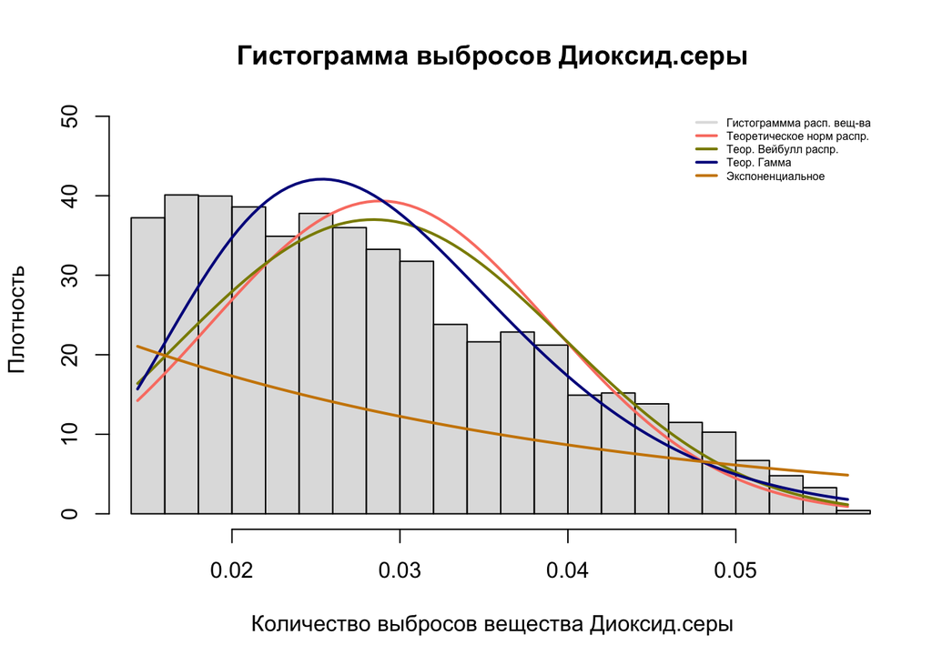

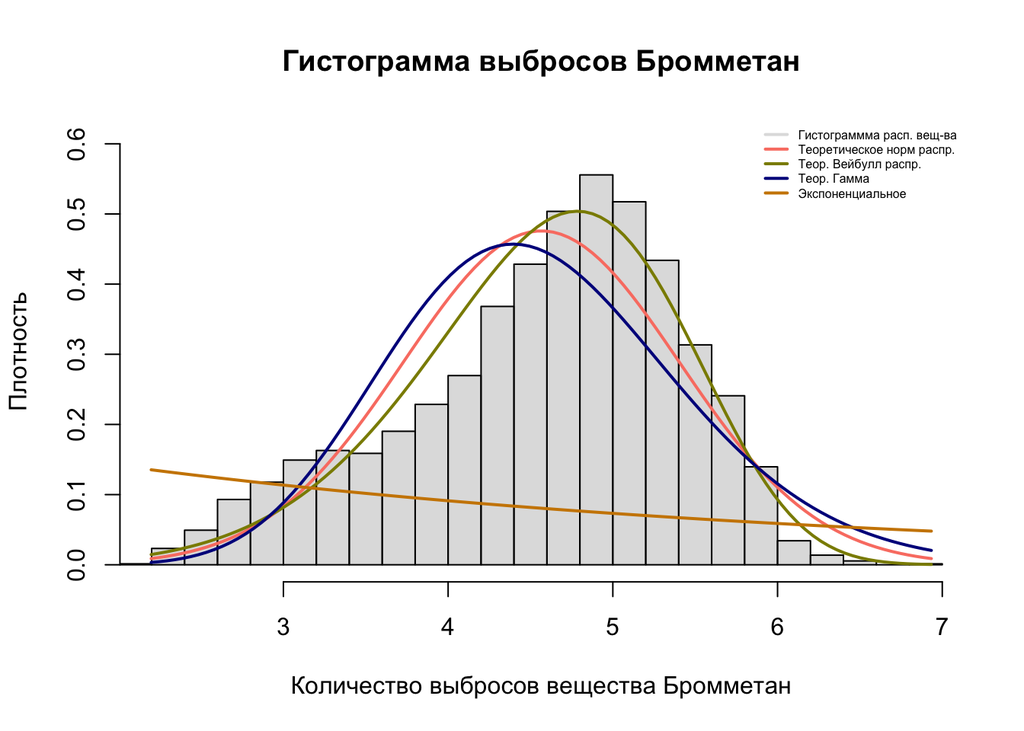

```r
library(fitdistrplus)

for (element in element_names) {
  current_data <- data1[[element]]

  y_max <- max(hist(current_data, plot = FALSE)$density) * 1.2
  x_range <- range(current_data)

  hist(current_data, freq = FALSE, breaks = "Scott",
       main = paste("Гистограмма выбросов", element),
       xlab = paste("Количество выбросов вещества", element),
       ylab = "Плотность", col = rgb(0.75, 0.75, 0.75, 0.5), border = "black",
       ylim = c(0, y_max), xlim = c(x_range[1], x_range[2]))

  x_vals <- seq(min(current_data), max(current_data), length.out = 100)

  if (all(current_data > 0)) {
    normal_params <- fitdist(current_data, "norm")
    lines(x_vals, dnorm(x_vals, mean = normal_params$estimate[1], sd = normal_params$estimate[2]), col = "salmon", lwd = 2)
  }

  weibull_params <- fitdist(current_data, "weibull")
  lines(x_vals, dweibull(x_vals, shape = weibull_params$estimate[1], scale = weibull_params$estimate[2]), col = "yellow4", lwd = 2)

  gamma_params <- fitdist(current_data, "gamma")
  lines(x_vals, dgamma(x_vals, shape = gamma_params$estimate[1], rate = gamma_params$estimate[2]), col = "blue4", lwd = 2)

  exp_params <- fitdist(current_data, "exp", method = "mme")
  lines(x_vals, dexp(x_vals, rate = exp_params$estimate[1]), col = "orange3", lwd = 2)

  legend("topright",
         legend = c("Гистограммма расп. вещ-ва",
                    "Теоретическое норм распр.",
                    "Теор. Вейбулл распр.",
                    "Теор. Гамма",
                    "Экспоненциальное"),
         col = c(rgb(0.75, 0.75, 0.75, 0.5),
                 "salmon",
                 "yellow4",
                 "blue4",
                 "orange3"),
         lwd = 2, bty = "n", cex = 0.5)

}
```

На графике гистограмма и плотности к распределению элементов ближе всего те же распределения, что были выявлены тестом Колмогорова-Смирнова

#### Задание 7: Оценить **вероятность суточного** **штрафа** каждого **вида** вредных веществ, при постоянном гипотетическом условии **наиболее неблагоприятного** ветра.

С помощью функции распределения F(x) оцениваем **вероятность того, что концентрация выброса вещества примет значение меньше предельно допустимой концентрации**

Для оценки вероятности превышения ПДК прямо над источником (трубой) используется формула:

P (Превышение ПДК) = 1 − F(ПДК)

Эта вероятность **не учитывает рассеивание** в городской среде

Чтобы определить концентрацию выбросов, которая может превысить ПДК в городе, необходимо скорректировать значение ПДК:

Необходимая концентрация выбросов у трубы = ПДК / Оценка эффективности

Это значение показывает, какая концентрация выбросов у трубы вызовет превышение ПДК в условиях конкретного коэффициента рассеивания.

*Вероятность суточного штрафа:*

Мы определяем вероятность того, что выбросы превысят ПДК **в юго-восточном направлении** — самом неблагоприятном для рассеивания ветра

Этот показатель позволяет оценить риск штрафов из-за превышения концентрации вредных веществ в конкретном направлении ветра.

```r
library(fitdistrplus)
A <- data2$ПДК
distributions <- c("empirical", "weibull", "empirical", "empirical", "empirical")
prob_less_than_pdk <- c(0, 0, 0, 0, 0)
prob_more_than_pdk_max_bad_cond <- c(1, 1, 1, 1, 1)
results <- list()
data4$Оценка.эффективности = as.numeric(data4$Оценка.эффективности)

for (i in 1:length(element_names)) {
  column_data <- na.omit(data1[[i + 1]])
  dist_type <- distributions[i]
  if (dist_type == "empirical") {
    ecdf_func <- ecdf(column_data)
    prob_less_than_pdk[i] <- ecdf_func(A[i] / max(data4$Оценка.эффективности))
  } else if (dist_type == "weibull") {
    weibull_params <- fitdist(column_data, "weibull")
    prob_less_than_pdk[i] <- pweibull(A[i] / max(data4$Оценка.эффективности), shape = weibull_params$estimate[1], scale = weibull_params$estimate[2])
  }
}
print(prob_less_than_pdk)
```

```
## [1] 1.0000000 0.7310719 0.4503148 0.9980838 0.8998084
```

```r
prob_more_than_pdk_max_bad_cond = 1 - prob_less_than_pdk
prob_daily_and_5years_fine <- data.frame(element_names, prob_more_than_pdk_max_bad_cond)
colnames(prob_daily_and_5years_fine) <- c("вещество", "вероятность суточного штрафа при самом неблагоприятном ветре")
head(prob_daily_and_5years_fine)
```

```
##       вещество вероятность суточного штрафа при самом неблагоприятном ветре
## 1       Аммиак                                                  0.000000000
## 2       Фосген                                                  0.268928082
## 3  Этиленоксид                                                  0.549685190
## 4 Диоксид.серы                                                  0.001916233
## 5    Бромметан                                                  0.100191623
```

- **Аммиак: 0**

  Вероятность суточного штрафа равна нулю. Это означает, что выбросы аммиака настолько малы, что даже при самом неблагоприятном ветре они не достигают ПДК.

  Вывод: аммиак в данных условиях безопасен и не приводит к штрафным ситуациям.
- **Фосген: 0.268928082**

  Вероятность суточного штрафа составляет ~26.89%. Это говорит о том, что в значительной части дней выбросы фосгена превышают ПДК, создавая риск штрафов.

  Вывод: фосген требует контроля и возможного снижения выбросов.
- **Этиленоксид: 0.549685190**

  Вероятность ~54.97%. Это означает, что больше половины дней выбросы этиленоксида приводят к превышению ПДК.

  Вывод: этиленоксид особенно опасен с точки зрения риска суточных штрафов, и меры по улучшению рассеивания или сокращению выбросов необходимы.
- **Диоксид серы: 0.001916233**

  Вероятность ~0.19%. Почти незначительная вероятность превышения ПДК.

  Вывод: диоксид серы в текущих условиях рассеивания безопасен.
- **Бромметан: 0.100191623**

  Вероятность ~10.02%. Это показывает, что в 1 из 10 дней концентрация бромметана превышает ПДК.

  Вывод: риск штрафов присутствует, но он относительно низкий.

*Для веществ с высокой вероятностью штрафов (фосген, этиленоксид) следует пересмотреть нормы выбросов, улучшить технологию рассеивания или снизить их объемы.*

*Для веществ с низкой вероятностью штрафов (диоксид серы, аммиак, бромметан) текущие условия выбросов и рассеивания эффективны.*

### Рассчитать совокупный штраф при данном условии

```r
prob_daily_and_5years_fine$количество_штрафных_дней_за_5_лет <- ceiling(prob_daily_and_5years_fine[["вероятность суточного штрафа при самом неблагоприятном ветре"]]*365*5) # использую ceiling, потому что дни только целые
prob_daily_and_5years_fine$штраф_за_5_лет <- prob_daily_and_5years_fine[['количество_штрафных_дней_за_5_лет']] * data2$`Штраф,.тыс.руб`
head(prob_daily_and_5years_fine)
```

```
##       вещество вероятность суточного штрафа при самом неблагоприятном ветре
## 1       Аммиак                                                  0.000000000
## 2       Фосген                                                  0.268928082
## 3  Этиленоксид                                                  0.549685190
## 4 Диоксид.серы                                                  0.001916233
## 5    Бромметан                                                  0.100191623
##   количество_штрафных_дней_за_5_лет штраф_за_5_лет
## 1                                 0              0
## 2                               491         100655
## 3                              1004         346380
## 4                                 4            560
## 5                               183          16470
```

В формуле используем вероятность суточного штрафа при самом неблагоприятном ветре, затем вычисляем колоичество штрафных дней за 5 лет, при данной вероятности. Затем, получаем общий штраф за 5 лет по каждому веществу.

**Результаты совокупного штрафа за 5 лет:**

### Отсеять такие вещества, для которых совокупный штраф заведомо меньше капитальных затрат

```r
df_penalty_kapital = data.frame(element_names, prob_daily_and_5years_fine$штраф_за_5_лет, data2$`Стоимость.системы,.тыс.руб.` + data2$`Стоимость.обслуживания,.тыс.руб.`*5)
colnames(df_penalty_kapital) <- c("вещество", "совокупный штраф за 5 лет", "Капитальные траты")
head(df_penalty_kapital)
```

```
##       вещество совокупный штраф за 5 лет Капитальные траты
## 1       Аммиак                         0              3812
## 2       Фосген                    100655              8980
## 3  Этиленоксид                    346380             12591
## 4 Диоксид.серы                       560              3579
## 5    Бромметан                     16470              2300
```

**Совокупный штраф заведомо меньше капитальных затрат для:**

- Аммиак
- Диоксид серы

  Можно допустить возможность получения штрафов, т.к. их накопленная сумма за 5 лет (срок службы очистного оборудования) будет меньше капитальных затрат на установку.

#### Для оставшихся веществ — составить формулу полной вероятности получения штрафа при условии разной интенсивности разных направлений ветров

Рассчитываем по формуле полной вероятности, чтобы учесть, как направления ветров и их интенсивность влияют на вероятность штрафов. Разные направления ветра разносят выбросы от трубы на различные расстояния и районы, изменяя концентрации загрязняющих веществ. Этот расчёт позволяет оценить совокупную вероятность превышения ПДК на основе метеоусловий.

**Найду вероятность отсутствия суточного штрафа для каждого из ветров**

Мы рассчитываем вероятность отсутствия штрафа для каждого из направлений ветра, чтобы понять, какие из них наиболее безопасны. Направления с наименьшей вероятностью штрафа предполагают меньшую экологическую нагрузку.

```r
A <- data2$ПДК
distributions <- c("weibull", "empirical", "empirical")
less_than_pdk_every_wind <- data.frame(matrix(nrow = 3, ncol = 6))
more_than_pdk_every_wind <- c(1, 1, 1)
results <- list()

for (i in c(2,3,5)) {
  column_data <- na.omit(data1[[i + 1]])
  dist_type <- distributions[match(i, c(2,3,5))]

  if (dist_type == "empirical") {
    ecdf_func <- ecdf(column_data)
    for (z in 3:8) {
      less_than_pdk_every_wind[match(i, c(2,3,5)), z - 2] <- ecdf_func(A[i] / data4$Оценка.эффективности[z])
    }
  } else if (dist_type == "weibull") {
    weibull_params <- fitdist(column_data, "weibull")
    for (z in 3:8) {
      less_than_pdk_every_wind[match(i, c(2,3,5)), z - 2] <- pweibull(A[i] / data4$Оценка.эффективности[z],
shape = weibull_params$estimate[1],
scale = weibull_params$estimate[2])
    }
  }
}

colnames(less_than_pdk_every_wind) <- data4$`Направление.ветра.(В.какую.сторону.дует.ветер)`[3:8]
rownames(less_than_pdk_every_wind) <- element_names[c(2, 3, 5)]

head(less_than_pdk_every_wind)
```

```
##                Восток Юго-восток        Юг Юго-запад Запад Северо-запад
## Фосген      0.9966619  0.7310719 0.8739327 0.9999526     1            1
## Этиленоксид 0.9737202  0.4503148 0.7432247 0.9939776     1            1
## Бромметан   1.0000000  0.8998084 0.9997263 1.0000000     1            1
```

**Найду вероятность суточного штрафа для каждого из ветров**

Вероятность штрафа для каждого ветра показывает, насколько сильное влияние оказывают те или иные метеоусловия на вероятность превышения ПДК. Это помогает выявить критические направления ветра, на которые стоит обратить особое внимание.

```r
more_than_pdk_every_wind <- less_than_pdk_every_wind
for (i in 1:3){
  for (j in 1:6){
    more_than_pdk_every_wind[i, j] <- 1 - more_than_pdk_every_wind[i, j]
  }
}
head(more_than_pdk_every_wind)
```

```
##                  Восток Юго-восток           Юг    Юго-запад Запад Северо-запад
## Фосген      0.003338087  0.2689281 0.1260672889 4.738033e-05     0            0
## Этиленоксид 0.026279770  0.5496852 0.2567752532 6.022447e-03     0            0
## Бромметан   0.000000000  0.1001916 0.0002737476 0.000000e+00     0            0
```

**Найду вероятность каждого из ветра**

Данные о распределении ветров позволяют связать вероятности штрафов с их частотой.

```r
wind_probability = data3[3:8,]
wind_probability$Cуточная_вероятность_ветра = wind_probability$Дней_в_году / 365
wind_probability
```

```
##             X1 Дней_в_году Cуточная_вероятность_ветра
## 3       Восток          57                 0.15616438
## 4   Юго-восток          34                 0.09315068
## 5           Юг          36                 0.09863014
## 6    Юго-запад          75                 0.20547945
## 7        Запад          71                 0.19452055
## 8 Северо-запад          30                 0.08219178
```

**Рассчитаем полную вероятность**

$P(\text{штраф}) = \sum_{i=1}^{8} P(\text{штраф} \mid \text{ветер}_i) \cdot P(\text{ветер}_i)$

```r
total_prob <- numeric(3)

for (w in 1:3) {
  total_prob[w] <- sum(
    more_than_pdk_every_wind [w,] * wind_probability$Cуточная_вероятность_ветра
  )
}


head(df_total_prob <- data.frame(Вещества = element_names[c(2, 3, 5)], Суточная_полная_вероятность_штрафа = total_prob))
```

```
##      Вещества Суточная_полная_вероятность_штрафа
## 1      Фосген                        0.038015895
## 2 Этиленоксид                        0.081870784
## 3   Бромметан                        0.009359918
```

### Рассчитать совокупный штраф по полной вероятности. Сопоставить капитальные затраты и совокупный вероятностный штраф.

```r
df_total_prob$Количество_штрафных_дней_за_5_лет = ceiling(df_total_prob$Суточная_полная_вероятность*365*5)
penalty = data2$`Штраф,.тыс.руб`[c(2,3,5)]
df_total_prob$Совокупный_штраф_за_5_лет = df_total_prob$Количество_штрафных_дней_за_5_лет * penalty
df_total_prob$Cтоимость_капитального_и_обслуживания = data2$`Стоимость.системы,.тыс.руб.`[c(2,3,5)] + data2$`Стоимость.обслуживания,.тыс.руб.`[c(2,3,5)]*5
head(df_total_prob)
```

```
##      Вещества Суточная_полная_вероятность_штрафа
## 1      Фосген                        0.038015895
## 2 Этиленоксид                        0.081870784
## 3   Бромметан                        0.009359918
##   Количество_штрафных_дней_за_5_лет Совокупный_штраф_за_5_лет
## 1                                70                     14350
## 2                               150                     51750
## 3                                18                      1620
##   Cтоимость_капитального_и_обслуживания
## 1                                  8980
## 2                                 12591
## 3                                  2300
```

- **Фосген**: Капитальные затраты (8980 руб.) ниже совокупного вероятностного штрафа (14350 руб.).
- **Этиленоксид**: Капитальные затраты (12591 руб.), совокупный штраф (51750 руб.)
- **Бромметан**: Капитальные затраты (2300 руб.), совокупный штраф (1620 руб.)

### Сделать вывод о стратегии по каждому типу вредных веществ:

#### **1. Аммиак**

- Совокупный штраф за 5 лет: 0 рублей.

  Капитальные затраты на установку оборудования: 3812 рублей.
- **Вывод:** не устанавливать оборудование и не платить штрафы, так как выбросы аммиака не приводят к превышению ПДК и штрафам.

#### **2. Фосген**

- Совокупный штраф за 5 лет: 14350 рублей.

  Капитальные затраты на установку оборудования: 8980 рублей.

  Суточная полная вероятность штрафа: 0.0380158950
- **Вывод:** штрафы превышают капитальные затраты на установку оборудования, соответственно, устанавливаем очистные оборудования

#### **3. Этиленоксид**

- Совокупный штраф за 5 лет: 51750 рублей.

  Капитальные затраты на установку оборудования: 12 591 рублей.

  Суточная полная вероятность штрафа: 0.0818707836
- **Вывод:** штрафы превышают капитальные затраты на установку оборудования, соответственно, устанавливаем очистные оборудования

#### **4. Диоксид серы**

- Совокупный штраф за 5 лет: 560 рублей.

  Капитальные затраты на установку оборудования: 3579 рублей.
- **Вывод:** штрафы не превышают капитальные затраты на установку оборудования, соответственно, допускаем уплату штрафов

#### **5. Бромметан**

- Совокупный штраф за 5 лет: 1620 рублей.

  Капитальные затраты на установку оборудования: 2300 рублей.

  Суточная полная вероятность штрафа: 0.009359918
- **Вывод:** штрафы не превышают капитальные затраты на установку оборудования, соответственно, допускаем уплату штрафов

#### Список литературы:

1. Эмпирические функции Смирнов Д.С.
2. Статистические тесты Смирнов Д.С.
3. Функции для формирования выборки Смирнов Д.С.
4. Пример использования циклов Смирнов Д.С.